[OHI Science](http://ohi-science.org) | [Citation policy](http://ohi-science.org/citation-policy/)

# OHI-Northeast: Region Options

Compiled on Tue Apr 25 16:06:08 2017 by afflerbach

I’ve created a few different options for delineating regions for the Northeast Ocean Health Index assessment. These are based on the various shapefiles and data that I could find while incorporating what I’ve learned about the region over the past few months. Using these different maps, it would be great if we could come up with one or two options to present to the RPB. I can generate additional options based on our discussion around these.

Main things to consider when looking at these maps:

1. Do we want regions divided along states? If so, should we keep these regions to 3nm, or extend them offshore.
2. Do we want to incorporate biogeographic boundaries, such as the Gulf of Maine, George’s Bank.
3. Do we want to have offshore regions extend to the 200 nm EEZ?

# 1 Marine Ecoregions and State Waters

This option combines two regional Marine Ecoregions (MEOWs), Gulf of Maine/Bay of Fundy and the Virginian regions, with state waters in the northeast. Massachusetts state waters are split into two regions where state waters meet the boundary between the two ecoregions. The offshore regions extend to the US EEZ.

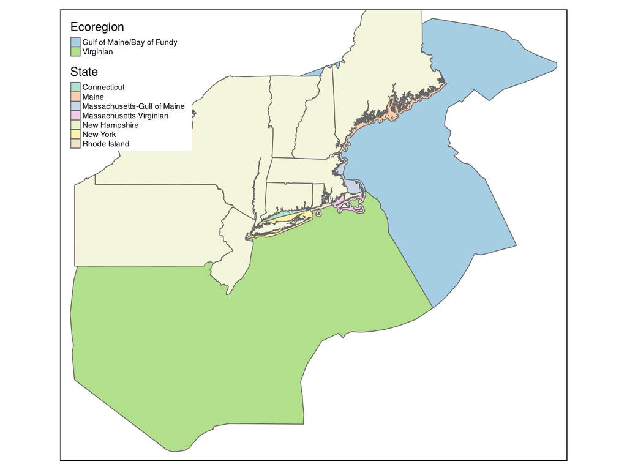

# 2 Marine Ecoregions and State Waters limited to the Northeast Ocean Planning Extent

Emily provided a single shapefile that delineates the planning region in the Northeast. The only change in this map is the offshore limit, based on this region.

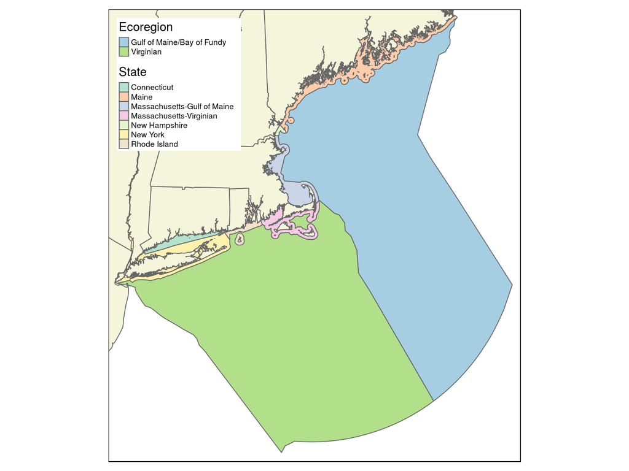

# 3 Adding in George’s Bank

I tried finding a good shapefile of George’s Bank but haven’t been able to find a great one, I’m hoping your expertise can help us make a decision about this. The best one I could find to represent George’s Bank is from the Herring Management Areas as [designated by NOAA](https://www.greateratlantic.fisheries.noaa.gov/educational_resources/gis/data/index.html):

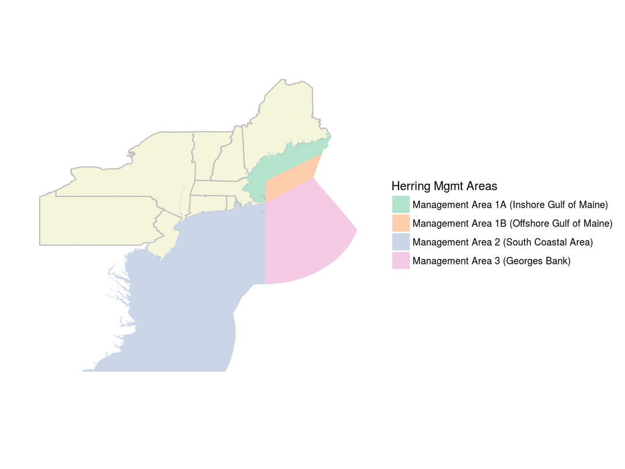

# 4 George’s Bank plus MEOW and State Waters

For this options I took the George’s Bank region from the Herring Management Areas and added it to the MEOW regions. If we do like this, we can find or make a different region for this.

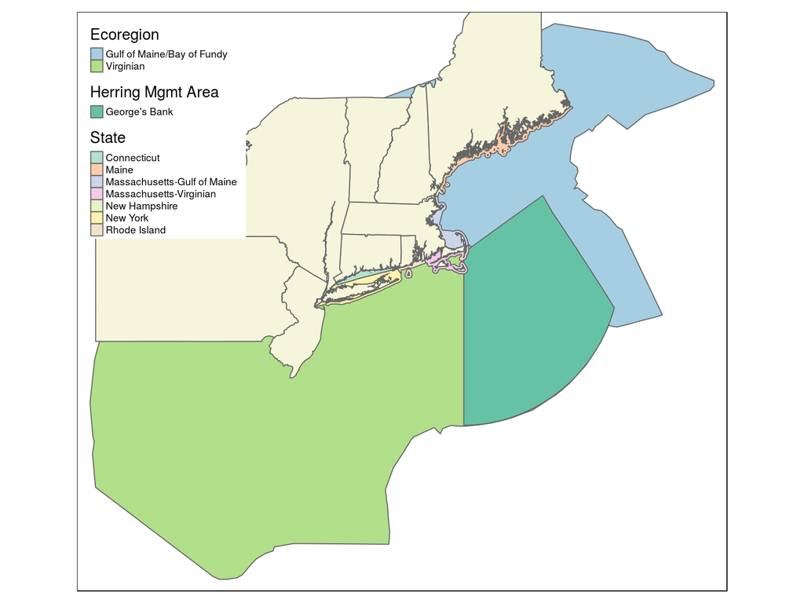

# 5 BOEM

The Bureau of Ocean Energy Management (BOEM) has delineated [Administrative Boundaries](http://www.boem.gov/Administrative-Boundaries/) in the Atlantic that extend from state waters to the US EEZ. These could be used to create offshore waters per state that extend beyond the 3 nm limit.

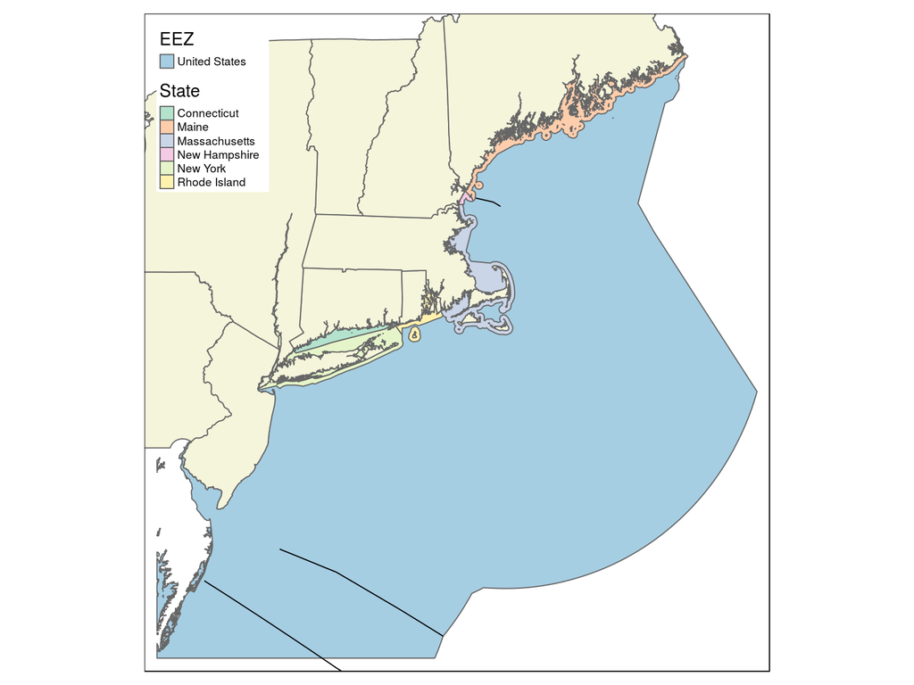

# 6 Ecological Production Unit Boundaries

Incorporating Ecological Production Units as an option for OHI regions.

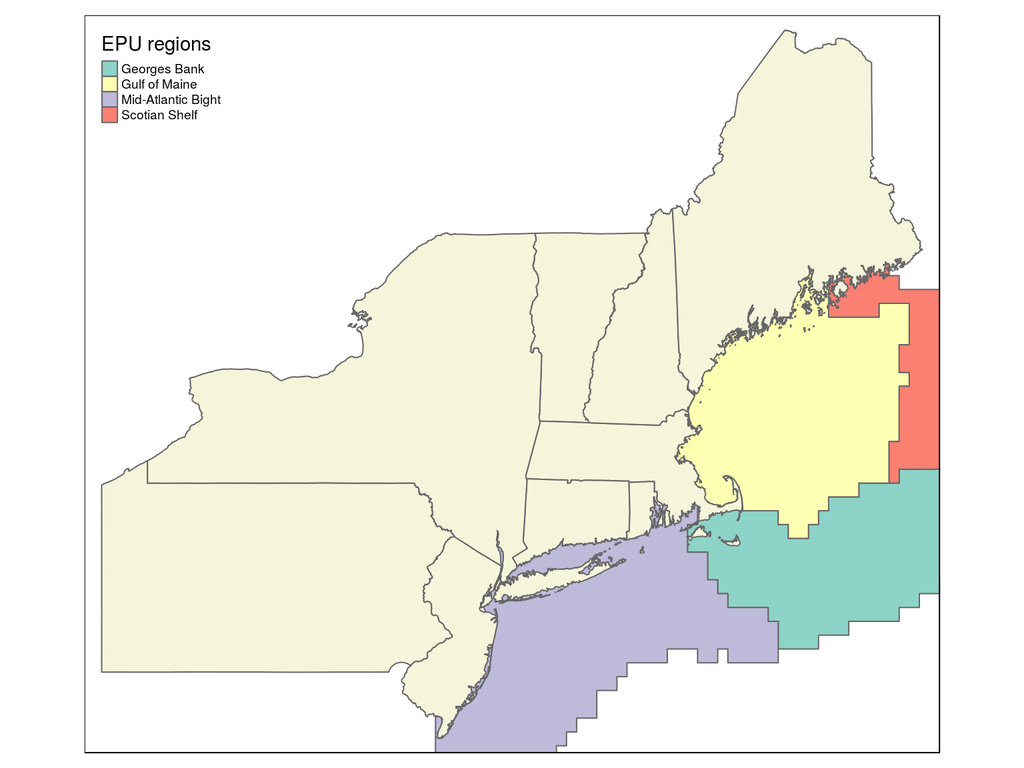

## 6.1 Map with EPU, state waters and RI OSAMP

Made this version of the map for the May 2 stakeholder workshop presentation.

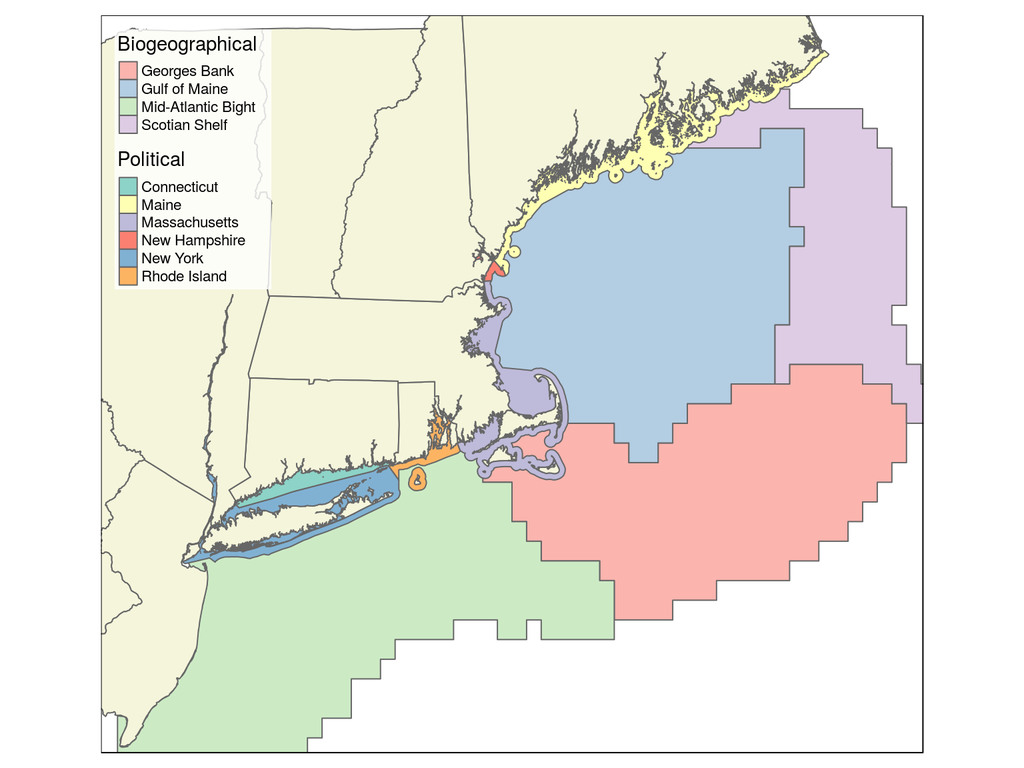

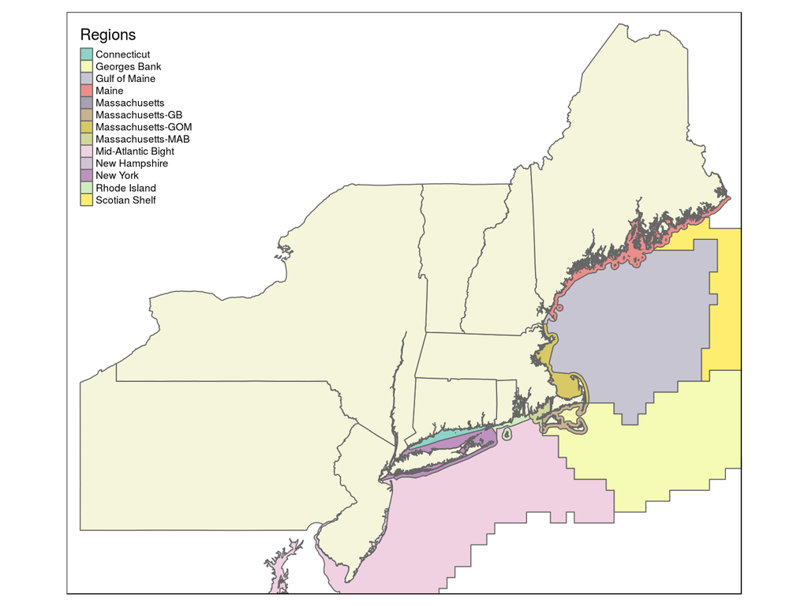

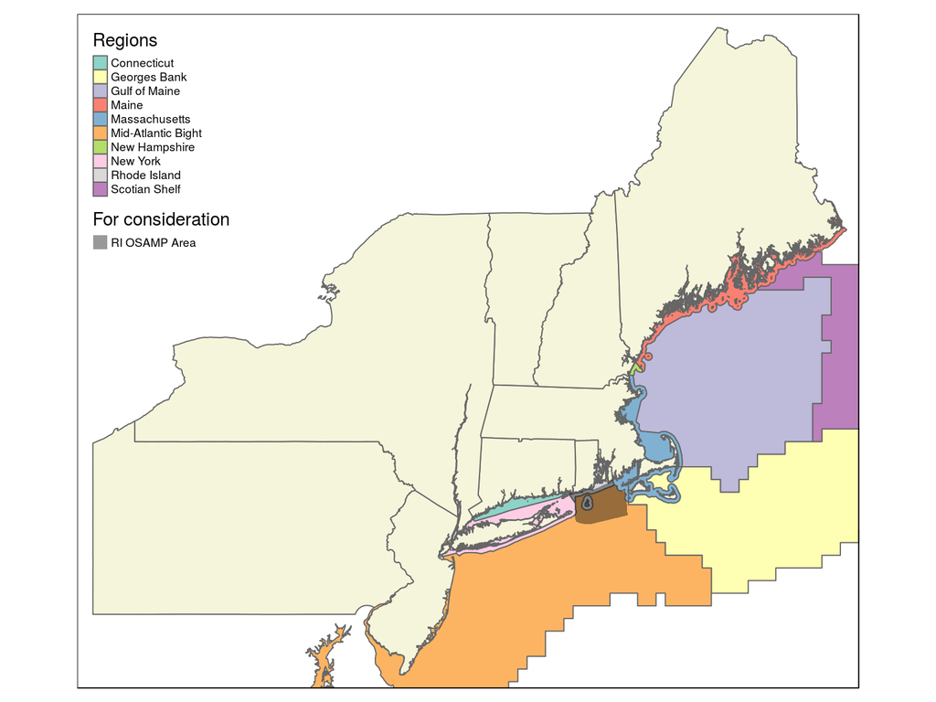

**OHI Northeast region options**: This map combines state waters and ecological production units (EPU’s) as defined by the Northeast Fisheries Science Center ([reference](http://www.nefsc.noaa.gov/program_review/background2016/6Ecosys%20D&PNew%20folder/Gamble/Gamble%20Ecological%20Production%20UnitsFin%20temp.pdf)) to create 10 regions for consideration. The Rhode Island OSAMP area is included for futher consideration as a region.